# Internet Speeds

## By: Brady Grundy, Dedrick Settles, Colin Sullivan, Daniel Lee

# Research Question:

## Do advertised internet speeds match actual internet speeds in the state of Maryland?

# Internet Speed

For many people in the United States, a stable and fast internet connection is becoming more of a necessity than a luxury. In a workplace, faster internet times means higher employee productivity and general consumer stability. Also, the US is seeing a rise in remote employees, or those that complete their work assignments from home. Having a stable internet speed is especially crucial for those that work remotely, because it is the only way they can transfer and receive data and, overall, be productive for their company. Students are also a demographic that heavily rely on stable and fast internet connections. Increasingly more homework assignments, exams, and projects can only be completed via the Internet.

# Internet Service Providers (ISP)

However, not everyone needs a strong internet connection. There are many people content with the minimum internet speeds that an ISP provides, which is why ISPs offer different selections of speeds and bandwidth amounts for their consumers. ISP’s provide telecommunication services including data communications access and telephone connection. They provide different plans for their customers, typically ranging from 15Mbps (megabits per second) to 1000Mbps. Bandwidth is a term that refers to the amount of data that can be transmitted over a network in a given amount of time. The data is measured in bits per second and download speeds are typically measured in megabytes (1 Mb = 8 megabits). This means that at a 1 megabit/s connection, 1 MB will take 8 seconds to download. In a more literal example, “The Dark Knight” is 1.7 gigabytes, which would take around 3.77 hours to download at 1 megabit/s.

# What it means for our research

For many people in the United States, their actual Internet speed is slower than what their Internet Service Provider advertises. The Internet service providers (ISPs) specify that the connection will be “up to” a certain speed because they can’t guarantee a dedicated connection. However, some people rely on having a strong connection for their jobs or for school where almost all assignments are turned in online, so it is very important for them to have the speed they pay for. Also, internet today is as important as cable and much more important than having a landline for most homes, making it more like a utility instead of just a luxury service.

# Description of Data

The data that we used came from many different sources. The first source that we used was the FCC form 477. The form 477 contains all data from all of the US States broadband providers about the speeds they advertise for their customers. We chose to use the June 2017 data for the state of Maryland which contained all data from 2016 as well. All data here was for only fixed broadband installations in Maryland but the satellite information is available. The data is available here: https://www.fcc.gov/general/broadband-deployment-data-fcc-form-477

The next dataset that we used was the FCC measuring broadband America report from 2016. This data included some visualizations of their data but we only used it for the median upload speed, and median download speeds in all of America. This data can be found here: https://www.fcc.gov/reports-research/reports/measuring-broadband-america/charts-measuring-broadband-america-2016

For finding the Maryland actual internet speed data we looked to the state of Maryland and their Maryland GIS data catalog. Maryland had a catalog of speed tests ran by residents in all of the counties in Maryland. This dataset was released in February of 2018, while there is no information that we could find of when exactly the speed tests were collected. The data was not as individual speed tests but pre aggregated broken down into counties, averaging the speed of the tests and noting how many tests in another column. Upload speed and download speed were broken into two different datasets but the number of tests in each dataset matched so we count them as one together. The datasets can be found here: http://data.imap.maryland.gov/datasets/maryland-broadband-speed-test-county-download and http://data.imap.maryland.gov/datasets/36a5ea158ab54401ad605c0a8377708a_4

The final dataset we used was to find the advertised county speeds. We did not find a dataset online for this so we created it ourselves. The data we created we manually pulled from broadbandnow.com. We chose to focus on four different counties. When pulling down the data we took the upload and download speeds in kilobits per second from the top three internet providers in each of our four counties. This data is from 2018 and is in the county_advertised.csv.

# How we processed the data

In processing our data we started with importing all of our datasets that we discussed above. The next step that we took was creating the overall Maryland ISP advertised speed dataset. This new dataset contained the average of all ISPs in Maryland with their average advertised upload and download for us to analyze later, we no longer show the actual tables since they are not necessary but for choosing what providers to focus on at the end we used this data. The next step we did was merging the Maryland county by county speed tests into a single dataset. This step was very easy since they had the exact same formats and we only needed a few important columns.

We also did some data wrangling outside of python, for our Nationwide Averages csv we took the data from the FCC report of American broadband and put it into our own csv that was much more manageable since it did not have consistent columns or rows before we did that.

The next step we did was taking the data that we extracted from broadbandnow.com and putting them into their own data frames for each county, averaging them, then saving those averages into a new data frame called county_advertised_scrape. This new data frame would contain the average advertised for our four main counties Montgomery, Prince George’s, Carroll and Talbot. We then had to manage the Maryland county data to fit with our new four chosen counties. To do so we deleted the rows for all unused counties, reset the index and saved this as a new data frame in order to not lose the original data. With the new data frame, we could then merge it with the chosen county advertised data creating a single data frame with both advertised speed and actual speed for our four important counties.

The final data process that we did was creating a new data frame to show average advertised download speed by company in Maryland. We chose to show this because it is good to see how companies are compared to each other but can not be compared to the county data as some speeds are only offered in certain areas.

```python
import pandas as pd
import numpy as np
import plotnine as p9
```

```python
maryland = pd.read_csv("MD_advertised.csv")
download = pd.read_csv("MD_down_county.csv")
upload = pd.read_csv("MD_up_county.csv")
nation = pd.read_csv("Nationwide Averages.csv")
county_advertised = pd.read_csv("county_advertised.csv")
```

```python
advertised = maryland[['DBAName', 'MaxAdDown', 'MaxAdUp']].groupby(['DBAName']).agg(['mean'])
```

```python
county_data= pd.merge(download, upload[['Min_Upload', 'Max_Upload', 'Ave_Upload', 'C0_NAME']], on='C0_NAME')

county_data.drop(['SHAPEarea','SHAPElen'], axis=1)
```

|  | OBJECTID | C0_NAME | Cnt_C0_NAME | Min_Download | Max_Download | Ave_Download | Min_Upload | Max_Upload | Ave_Upload |
| --- | --- | --- | --- | --- | --- | --- | --- | --- | --- |
| 0 | 1 | Allegany | 383 | 0 | 225930 | 8696.577023 | 34 | 38015 | 2683.971279 |
| 1 | 2 | Anne Arundel | 1904 | 0 | 208803 | 16184.321429 | 46 | 71204 | 5996.515756 |
| 2 | 3 | Baltimore | 2610 | 0 | 262450 | 18535.531801 | 49 | 216038 | 5613.704981 |
| 3 | 4 | Baltimore City | 1955 | 27 | 175997 | 11553.283887 | 5 | 84693 | 3227.357545 |
| 4 | 5 | Calvert | 319 | 47 | 54814 | 12195.250784 | 50 | 11656 | 2883.808777 |
| 5 | 6 | Caroline | 141 | 0 | 61143 | 6603.574468 | 30 | 14328 | 1556.957447 |
| 6 | 7 | Carroll | 637 | 0 | 77593 | 9562.478807 | 15 | 62932 | 2677.238619 |
| 7 | 8 | Cecil | 247 | 40 | 85826 | 7612.412955 | 9 | 83685 | 2374.202429 |
| 8 | 9 | Charles | 929 | 0 | 160807 | 7623.145318 | 14 | 37232 | 2107.238967 |
| 9 | 10 | Dorchester | 185 | 23 | 38422 | 6961.681081 | 5 | 13479 | 2485.572973 |
| 10 | 11 | Frederick | 759 | 0 | 120744 | 12138.445323 | 20 | 29140 | 3468.940711 |
| 11 | 12 | Garrett | 182 | 12 | 37945 | 4635.159341 | 38 | 19100 | 1694.236264 |
| 12 | 13 | Harford | 766 | 38 | 78210 | 12672.762402 | 18 | 26641 | 4030.244125 |
| 13 | 14 | Howard | 1419 | 33 | 209861 | 16540.265680 | 38 | 54782 | 5899.780127 |
| 14 | 15 | Kent | 142 | 0 | 51360 | 5981.387324 | 26 | 36675 | 2208.669014 |
| 15 | 16 | Montgomery | 3967 | 0 | 167328 | 15279.234686 | 4 | 85400 | 5456.099824 |
| 16 | 17 | Prince George's | 1410 | 10 | 238631 | 14313.640426 | 8 | 135334 | 5787.687234 |
| 17 | 18 | Queen Anne's | 205 | 215 | 65688 | 5429.278049 | 31 | 36130 | 1226.580488 |
| 18 | 19 | Somerset | 179 | 0 | 44419 | 4634.759777 | 50 | 16513 | 1274.407821 |
| 19 | 20 | St. Mary's | 772 | 22 | 68837 | 6415.830311 | 22 | 23209 | 943.321244 |
| 20 | 21 | Talbot | 273 | 21 | 35443 | 4489.622711 | 3 | 8691 | 803.443223 |
| 21 | 22 | Washington | 456 | 54 | 722558 | 14516.741228 | 71 | 42542 | 2322.627193 |
| 22 | 23 | Wicomico | 800 | 16 | 109475 | 15077.152500 | 34 | 36432 | 4224.990000 |
| 23 | 24 | Worcester | 315 | 19 | 46292 | 8564.266667 | 17 | 50659 | 2529.311111 |

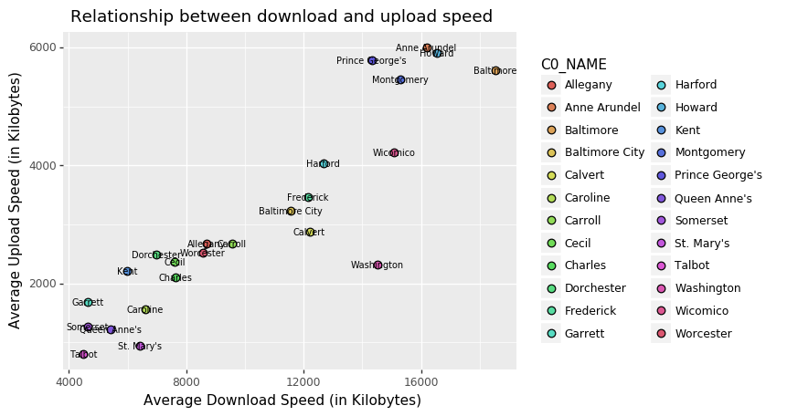

```python
(p9.ggplot(county_data) +
    p9.aes(x = 'Ave_Download', y = 'Ave_Upload', fill = 'C0_NAME') +
    p9.geom_point(size = 3) +
    p9.geom_text(p9.aes(label='C0_NAME'),size = 7) +
    p9.ggtitle('Relationship between download and upload speed') +
    p9.ylab('Average Upload Speed (in Kilobytes)') +
    p9.xlab('Average Download Speed (in Kilobytes)'))
```

```python
montgomery= county_advertised.loc[county_advertised['county'] == 'Montgomery ']
mont_up= montgomery['up_speed'].mean()
mont_down=montgomery['down_speed'].mean()

pg= county_advertised.loc[county_advertised['county'] == "Prince Geroge's"]
pg_up=pg['up_speed'].mean()
pg_down=pg['down_speed'].mean()

carroll= county_advertised.loc[county_advertised['county'] == "Carroll"]
carroll_up=carroll['up_speed'].mean()
carroll_down=carroll['down_speed'].mean()

talbot= county_advertised.loc[county_advertised['county'] == "Talbot"]
talbot_up=talbot['up_speed'].mean()
talbot_down=talbot['down_speed'].mean()

county_advertised_scrape=pd.DataFrame({'county':['Montgomery', "Prince George's", 'Carroll', 'Talbot'], 'ADV_AVG_UP':[mont_up, pg_up, carroll_up, talbot_up], 'ADV_AVG_DOWN':[mont_down, pg_down, carroll_down, talbot_down]})
county_advertised_scrape
```

|  | county | ADV_AVG_UP | ADV_AVG_DOWN |
| --- | --- | --- | --- |
| 0 | Montgomery | 32600.000000 | 64766.666667 |
| 1 | Prince George's | 31766.666667 | 45166.666667 |
| 2 | Carroll | 34600.000000 | 66766.666667 |
| 3 | Talbot | 766.666667 | 12433.333333 |

```python
limited_counties=county_data
limited_counties= limited_counties.drop([0,1,2,3,4,5, 7,8,9,10,11,12, 13, 14, 17, 18, 19,21, 22,23])
limited_counties=limited_counties.reset_index(drop=True)
limited_counties
merged_counties=limited_counties.merge(county_advertised_scrape, left_on='C0_NAME', right_on='county', how='inner')
```

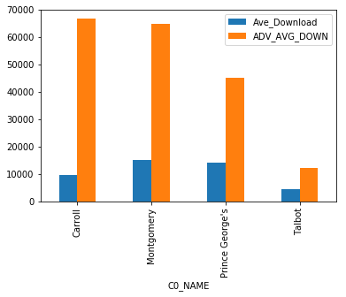

```python
merged_counties.plot.bar(x='C0_NAME', y=['Ave_Download', 'ADV_AVG_DOWN'])
```

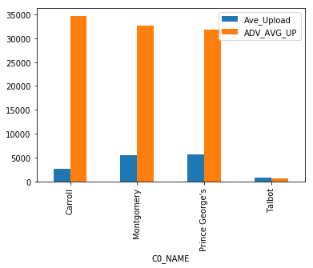

```python
merged_counties.plot.bar(x='C0_NAME', y=['Ave_Upload', 'ADV_AVG_UP'])
```

```python
merged_counties_long = pd.melt(merged_counties, id_vars='C0_NAME',
        value_vars=['Ave_Upload', 'ADV_AVG_UP'], var_name='Upload Type',
        value_name='values')
```

[figure not shown]

```python
(p9.ggplot(merged_counties_long) +
  p9.aes(x='C0_NAME', y='values', fill='Upload Type') +
  p9.geom_bar(stat="identity", position='dodge')+
  p9.ggtitle('Average Download Speeds by Company') +
    p9.ylab('Speed (in Kilobytes)') +
    p9.xlab('County Name')
)
```

```python
advertised_filtered=pd.DataFrame({'DBAName':['Comcast','Verizon Maryland LLC','Ting','RCN','Anne Arundel Broadband'], 'MaxAdDown':[272.229702,266.027794,600.5,319.101149,65.825243], 'MaxAdUp':[9.347019,246.318891,600.5,17.844598,5.000000]})
```

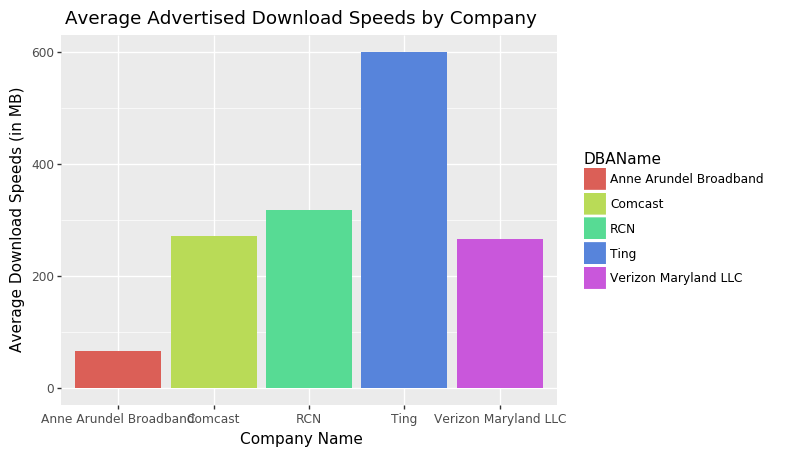

```python
(p9.ggplot(advertised_filtered) +
  p9.aes(x='DBAName', y='MaxAdDown', fill='DBAName') +
  p9.geom_bar(position='dodge',stat="identity")+
  p9.ggtitle('Average Advertised Download Speeds by Company') +
    p9.ylab('Average Download Speeds (in MB)') +
    p9.xlab('Company Name')
)
```